# Proteogenomic data processing

```r
library(knitr)
```

## Proteogenomic Data Provenance

In this document we process 105 matched breast tumour samples that are sourced from The Cancer Genome Atlas (TCGA). Assays on these 105 samples generated protein quantification, mRNA expression, and copy number alteration (CNA) forming a framework for proteogenomic analysis. All proteogenomic data in evaluating `spacemap` was sourced from the [Breast Cancer Proteogenomics Landscape Study, Nature 2016](https://cptac-data-portal.georgetown.edu/cptac/s/S029) (BCPLS).The protein identification and quantitation data had been previously processed according to the Common Data Analysis Pipeline [(CDAP)](https://cptac-data-portal.georgetown.edu/cptac/aboutData/show?scope=dataLevels) of the of the Clinical Proteomics Tumor Analysis Consortium (CPTAC). Michael Gatza, an author of BCPLS, was involved in the processed the RNA-seq gene expression data set, which has been normalized, log transformed, median centered, and filtered to contain only those genes present in >80% of samples. Pei Wang, another author of BCPLS, called gains and losses in aCGH data with the [‘Cluster along chromosomes algorithm’](http://biostatistics.oxfordjournals.org/content/6/1/45).

There are 108 samples of breast cancer tumours, 3 of which are not included because they were normal controls. The meta-data associated with the CPTAC experiment is listed in the following data.frame:

```r
basedir <- "~/scratch-data//neta-bccptac/data/"
clin <- read.csv(file = file.path(basedir,"tumor-metadata.csv"), header = TRUE)
head(clin)
```

```
##    Sample iTRAQ.Experiment.number PAM50 ER.Status PR.Status HER2.Status
## 1 C8-A131                       1 Basal  Negative  Negative    Negative
## 2 BH-A18Q                       2 Basal  Negative  Negative    Negative
## 3 BH-A0AV                       5 Basal  Negative  Negative    Negative
## 4 A2-A0D0                       6 Basal  Negative  Negative    Negative
## 5 A2-A0CM                       7 Basal  Negative  Negative    Negative
## 6 AR-A0U4                       9 Basal  Negative  Negative    Negative
```

## RNA data processing

Read in the RNA-seq expression data and the gene-level copy number variation (CNV) data. Although we will not use the gene-level CNV data, it is helpful for identifying sample names.

```r
rna <- read.delim(file = file.path(basedir, "rna-seq-data-v1.txt"), header = TRUE, sep = "\t")
cnv <- read.delim(file = file.path(basedir, "CNA-data-v1.txt"), header = TRUE, sep = "\t")
```

### Keep only 77 high quality samples

There are only 77 high quality samples from the protein quantitation assays, which requires us to subset from the 105 RNA-seq assays. The high quality sample IDs are contained in Pei Wang’s clustering of the aCGH data. Load this analysis in preparation to extract out the high quality sample IDs.

```r
pwf <- new.env()
load(file = file.path(basedir, "cnv.data.80.RData"), envir = pwf)
```

In order to reformat the RNA-seq raw data to contain only 77 samples of sufficiently high quality, we must find the high quality sample identifier, which is only a substring contained within of the column names of Pei’s aCGH analysis. Create an ID map to extract the high quality samples.

```r
#drop the control, normal sample ids
idMap <- data.frame(sampleID = clin$Sample[-c(106,107, 108)])
#obtain the abbreviated sample ids
idMap$rnaOrder <- sub(pattern = ".", replacement = "-", fixed = TRUE,
                      x = substr(x = colnames(rna)[2:length(colnames(rna))],
                                 start = 6, stop = 12))
#indicate which column indices
idMap$rnaIndex <- 2:length(colnames(rna))
idMap$cnvOrder <- sub(pattern = ".", replacement = "-", fixed = TRUE,
                      x = substr(x = colnames(cnv)[4:length(colnames(cnv))],
                                 start = 6, stop = 12))
idMap$cnvIndex <- 4:length(colnames(cnv))

#assure sample columns for rna, cnv are the same order
stopifnot(identical(idMap$rnaOrder, idMap$cnvOrder))
#assure unique abreviated sample ids before using grep
stopifnot(!anyDuplicated(idMap$rnaOrder))
stopifnot(!anyDuplicated(pwf$cnv.part))
idMap$highQual <- FALSE
highQualIndex <- sapply(pwf$cnv.part, function(x) {
  idx <- grep(x, idMap$rnaOrder)
  if (length(idx))
    return(idx)
  else
    return(NA)
})
# make sure no high quality samples are missing from search
stopifnot(!any(is.na(highQualIndex)))
idMap$highQual[highQualIndex] <- TRUE
```

After some processing, we have a data.frame indicating unique sample ID’s, the index in which they appear in the `rna` and `cnv` variangles, as well as a logical indicating high quality samples.

```r
head(idMap)
```

```
##   sampleID rnaOrder rnaIndex cnvOrder cnvIndex highQual
## 1  C8-A131  A2-A0CM        2  A2-A0CM        4     TRUE
## 2  BH-A18Q  A2-A0D0        3  A2-A0D0        5    FALSE
## 3  BH-A0AV  A2-A0D1        4  A2-A0D1        6    FALSE
## 4  A2-A0D0  A2-A0D2        5  A2-A0D2        7     TRUE
## 5  A2-A0CM  A2-A0EQ        6  A2-A0EQ        8     TRUE
## 6  AR-A0U4  A2-A0EV        7  A2-A0EV        9     TRUE
```

Record the high quality clinical information with samples sorted in the same order as RNA.

```r
clin.hq <- clin[match(idMap$rnaOrder[idMap$highQual], clin$Sample),]
```

Subset the high quality samples.

```r
rna.hq <- as.matrix(rna[,idMap$rnaIndex[idMap$highQual]])
cnv.hq <- as.matrix(cnv[,idMap$cnvIndex[idMap$highQual]])
rownames(cnv.hq) <- cnv$Gene.Symbol
rownames(rna.hq) <- rna$CLID
```

### Inspect gene identifiers.

The gene symbols are not entirely unique, 12 of them having duplicates.

```r
symbol <- unlist(lapply(strsplit(x = as.character(rna$CLID), split = "|", fixed = TRUE), function(x) x[1]))
dupSymbolIndex <- duplicated(symbol)
sum(dupSymbolIndex)
```

```
## [1] 12
```

The entrez gene identifiers are unique.

```r
entrezgene <- unlist(lapply(strsplit(x = as.character(rna$CLID), split = "|", fixed = TRUE), function(x) x[2]))
dupEntrezGeneIndex <- duplicated(entrezgene)
sum(dupEntrezGeneIndex)
```

```
## [1] 0
```

### Filter RNA-seq expression with high missing value rates

Remove genes that exceed 30% of samples with missing values.

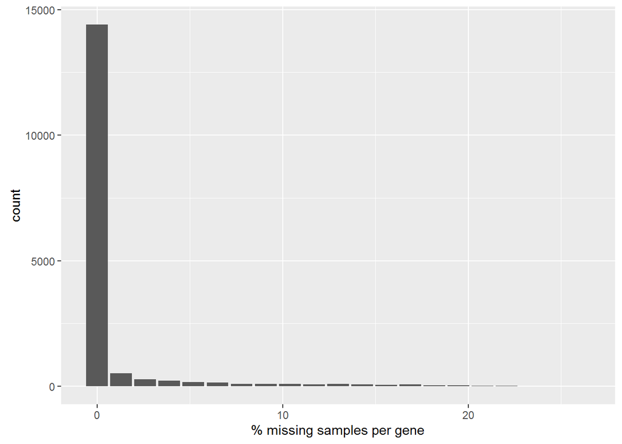

```r
library(ggplot2)
gnumNA <- sapply(seq_len(nrow(rna.hq)), function(i) sum(is.na(rna.hq[i,])))
missingRateThresh <- 0.30
qplot(gnumNA / ncol(rna.hq)*100, geom = "bar") + xlab("% missing samples per gene")
```

No gene needs to be filtered out on this criteria. In fact, the degree of missingness is low in the CPTAC RNA-seq dataset. In future processing of the data, missing values will be imputed with mean zero after standardization.

```r
stopifnot(!any(gnumNA > missingRateThresh*ncol(rna.hq)))
```

### Keep high variance genes for network analysis

Computational limits of `spaceMap` and `sCGGM` require us to filter out genes that do not exhibit high variance. Restrict the analysis to mRNA that exceed the 90th percentile in gene variation.

```r
rna.sd <- apply(rna.hq, MARGIN = 1, FUN = sd, na.rm = TRUE)
keepRNAIndex <- rna.sd > quantile(x = rna.sd, probs = 0.90)
```

Include some cis genes that are positive controls of the 17q12 amplicon that may not have passed the high variance filter.

```r
rna_entrez <- unlist(lapply(strsplit(x = as.character(rownames(rna.hq)), split = "|", fixed = TRUE), function(x) x[2]))
rna_symbol <- unlist(lapply(strsplit(x = as.character(rownames(rna.hq)), split = "|", fixed = TRUE), function(x) x[1]))
rna_symbol <- ifelse(rna_symbol == "?", rna_entrez, rna_symbol)
pc_index <- match(c("ERBB2", "ERBB4", "GRB7", "KRT17", "KRT19", "PNMT"), rna_symbol)
final_keep_rna_index <- sort(union(pc_index, which(keepRNAIndex)))
rnatofit <- rna.hq[final_keep_rna_index,]
```

The total number of mRNA expression considered for this analysis is:

```r
nrow(rnatofit)
```

```
## [1] 1657
```

Mean-center mRNA features and scale by standard deviation. Follow this action by imputing mean-zero for missing values.

```r
#transpose to be n x p dimension
rnatofit_t <- t(rnatofit)
#standardize features
rnatofit_t <- scale(rnatofit_t)
#zero-mean imputation for mRNA
rnatofit_t[is.na(rnatofit_t)] <- 0
rnatofit_std <- t(rnatofit_t)
```

### Form an `BioBase::ExpressionSet` for mRNA data.

Associate the correct sample meta data from TCGA with the mRNA expression data.

```r
ltcga_data <- strsplit(x = colnames(rnatofit_std), split = ".", fixed = T)
tcga_vars <- c("Project", "Location", "Study_Participant", "Sample_Type", "Portion", "Plate_Order", "Center")
ltcga_data2 <- lapply(ltcga_data, function(l) {
  names(l) <- tcga_vars
  as.data.frame(t(data.frame(l)))
})
suppressPackageStartupMessages(library(data.table))
tcga_sample_info <- rbindlist(ltcga_data2)
head(tcga_sample_info)
```

```
##    Project Location Study_Participant Sample_Type Portion Plate_Order
## 1:    TCGA       A2              A0CM         01A     31R        A034
## 2:    TCGA       A2              A0D2         01A     21R        A034
## 3:    TCGA       A2              A0EQ         01A     11R        A034
## 4:    TCGA       A2              A0EV         01A     11R        A034
## 5:    TCGA       A2              A0EX         01A     21R        A034
## 6:    TCGA       A2              A0EY         01A     11R        A034
##    Center
## 1:     07
## 2:     07
## 3:     07
## 4:     07
## 5:     07
## 6:     07
```

Combine this information with other clinical features previously imported.

```r
pheno_data <- cbind(clin.hq, tcga_sample_info)
#simplify sample id now that we have extracted the information encoded therein (see previous block)
colnames(rnatofit_std) <- clin.hq$Sample
row.names(pheno_data) <- colnames(rnatofit_std)
```

Provide additional information on the sample covariates in the form of meta data.

```r
suppressPackageStartupMessages(library(Biobase))
meta_data <- data.frame(labelDescription = c("Tissue Location - Study Participant",
                                             "iTRAC experiment number",
                                             "50 genes used to classify breast cancer subtypes",
                                             "Estrogen Receptor Status",
                                             "Progesterone Receptor Status",
                                             "HER2 Subtype",
                                             "Project",
                                             "Location where the samples and the clincal metadata were collected",
                                             "Study Participant",
                                             "Sample and vial (01 = solid tumor, A = The first vial in a sequence of samples)",
                                             "order of portion in a sequence of 100 - 120 mg samples",
                                             "order of plate in a sequence of 96-well plates",
                                             "Center that will receive the sample"),
                        row.names = colnames(pheno_data))
pheno_data <- new("AnnotatedDataFrame",
                 data=pheno_data, varMetadata=meta_data)
pheno_data
```

```
## An object of class 'AnnotatedDataFrame'
##   rowNames: A2-A0CM A2-A0D2 ... E2-A15A (77 total)
##   varLabels: Sample iTRAQ.Experiment.number ... Center (13 total)
##   varMetadata: labelDescription
```

#### Annotate mRNA features.

Identify the entrez gene and symbol features in the data. If a symbol is missing, replace it with its entrez gene id.

```r
rna_entrez <- unlist(lapply(strsplit(x = as.character(rownames(rnatofit_std)), split = "|", fixed = TRUE), function(x) x[2]))
rna_symbol <- unlist(lapply(strsplit(x = as.character(rownames(rnatofit_std)), split = "|", fixed = TRUE), function(x) x[1]))
rna_symbol <- ifelse(rna_symbol == "?", rna_entrez, rna_symbol)
```

Import the Bioconductor package `org.Hs.eg.db` regarding the **homo sapien** annotation. Prepare a function to extract mapped key values from entrez id features in the requested database.

```r
suppressWarnings(library(org.Hs.eg.db))
```

```r
hs_feature_list <- function(db, eg) {
  mk <- mappedkeys(db)
  xx <- as.list(db[eg[eg %in% mk]])
}
```

Extract the chromosome, first start and last stop coordinates, as well as the strand of the mRNA features. Maintain these attributes in list format since some of the genes do not have complete information on the attributes (e.g. strand information missing).

```r
start_chrloc <- hs_feature_list(org.Hs.egCHRLOC, rna_entrez)
rna_preattr <- list(chr = unlist(hs_feature_list(org.Hs.egCHR, rna_entrez)),
                   start =  sapply( hs_feature_list(org.Hs.egCHRLOC, rna_entrez), function(x) min(abs(x))),
                   end =  sapply(hs_feature_list(org.Hs.egCHRLOCEND, rna_entrez), function(x) max(abs(x))),
                   strand = ifelse(sapply(start_chrloc, function(x) sign(min(x))) == 1L, "+", "-"))
```

Reformat the list into a data.frame that can be stored in an `Biobase::ExpressionSet` object.

```r
suppressPackageStartupMessages(library(foreach))
lrna_node_atttributes <- foreach(id = rna_entrez, sym = rna_symbol) %do% {
  id_attr <- sapply(rna_preattr, function(a) {
    b <- a[names(a) %in% id]
    ifelse(length(b), b, NA)
  })
  names(id_attr) <- names(rna_preattr)
  id_attr_df <- as.data.frame(t(data.frame(id_attr)),  stringsAsFactors = F, row.names = "")
  id_attr_df$start <- as.integer(id_attr_df$start)
  id_attr_df$end <- as.integer(id_attr_df$end)
  id_attr_df$id <- id
  id_attr_df$symbol <- sym
  id_attr_df$cyto <- NA
  id_attr_df$type <- "y"
  id_attr_df$cytoscape <- sym
  id_attr_df$chr <- paste0("chr", id_attr_df$chr)
  id_attr_df[,c(5,1,2,3,6,7,4,8,9)]
}
rna_node_attributes <- as.data.frame(rbindlist(lrna_node_atttributes))
rownames(rna_node_attributes) <- rna_node_attributes$id
head(rna_node_attributes)
```

```
##            id   chr     start       end   symbol cyto strand type
## 143941 143941 chr11 118398209 118401740    TTC36   NA      +    y
## 54596   54596  chr1  62660473  62678001    L1TD1   NA      +    y
## 2151     2151  chr5  75911306  75919259    F2RL2   NA      -    y
## 23017   23017 chr12  50260678  50297760    FAIM2   NA      -    y
## 9856     9856  chr6  24544331  24646383 KIAA0319   NA      -    y
## 164284 164284 chr20  57034159  57089994  APCDD1L   NA      -    y
##        cytoscape
## 143941     TTC36
## 54596      L1TD1
## 2151       F2RL2
## 23017      FAIM2
## 9856    KIAA0319
## 164284   APCDD1L
```

```r
#evidence of limited attributes
#rna_node_attributes[is.na(rna_node_attributes$strand),]
```

Create the final mRNA `ExpressionSet` object.

```r
#subset high quality samples
idMapHq <- idMap[idMap$highQual,]
#assure sample order correct
stopifnot(identical(as.character(clin.hq$Sample), idMapHq$rnaOrder),
          identical(as.character(clin.hq$Sample), idMapHq$cnvOrder))
suppressPackageStartupMessages(library(Biobase))
rownames(rnatofit_std) <- rownames(rna_node_attributes)
rnaset <- ExpressionSet(assayData = rnatofit_std,
                        phenoData = pheno_data,
                        featureData =  AnnotatedDataFrame(data = rna_node_attributes))
rnaset
```

```
## ExpressionSet (storageMode: lockedEnvironment)
## assayData: 1657 features, 77 samples
##   element names: exprs
## protocolData: none
## phenoData
##   sampleNames: A2-A0CM A2-A0D2 ... E2-A15A (77 total)
##   varLabels: Sample iTRAQ.Experiment.number ... Center (13 total)
##   varMetadata: labelDescription
## featureData
##   featureNames: 143941 54596 ... 9760 (1657 total)
##   fvarLabels: id chr ... cytoscape (9 total)
##   fvarMetadata: labelDescription
## experimentData: use 'experimentData(object)'
## Annotation:
```

## Protein Quantitation Processing

The protein quantitation data contains the 77 high quality samples plus a few normal tissue samples. The data has been normalized and missing data has been filtered away previously. Read in the data.

```r
prot <- read.delim(file = file.path(basedir, "proteome-ratio-norm-noNA-unimodal-edit-header.gct"), header = TRUE, sep = "\t")
#exclude 3 normal control samples
prot <- prot[,-c((ncol(prot) - 2):ncol(prot))]
```

Reformat the sample-level ids from the protein file to match that found in the clinical meta data file.

```r
pid <- gsub(pattern = ".", replacement = "-", fixed = TRUE,
            x = substr(x = colnames(prot)[3:length(colnames(prot))],
                       start = 1, stop = 7))
head(pid)
```

```
## [1] "AO-A12D" "C8-A131" "AO-A12B" "BH-A18Q" "C8-A130" "C8-A138"
```

Duplicate sample IDs exist, which correspond to technical replicates. There are three sample ids with two technical replicates.

```r
dupids <- pid[which(duplicated(pid))]
dupids
```

```
## [1] "AO-A12D" "C8-A131" "AO-A12B"
```

Identify the technical replicates.

```r
#extract an extended id including the technical replicate id.
pid2 <- gsub(pattern = ".", replacement = "-", fixed = TRUE,
             x = substr(x = colnames(prot)[3:length(colnames(prot))], start =  1, stop = 10))
#assure there is not duplicates among extended id
stopifnot(!anyDuplicated(pid2))
techreps <- sapply(dupids, function(di) pid2[grep(di, pid2)])
rownames(techreps) <- paste0("replicate-", 1:2)
kable(techreps)
```

|  | AO-A12D | C8-A131 | AO-A12B |
| --- | --- | --- | --- |
| replicate-1 | AO-A12D-01 | C8-A131-01 | AO-A12B-01 |
| replicate-2 | AO-A12D-05 | C8-A131-32 | AO-A12B-34 |

Obtain the corresponding technical replicate indices in the extended protein sample ID variable `pid2`.

```r
trepids <- sapply(dupids, function(pat) grep(pattern = pat, x = pid2))
```

The correlation between technical replicates is sufficiently high. We replace each technical replicate measurements with the average.

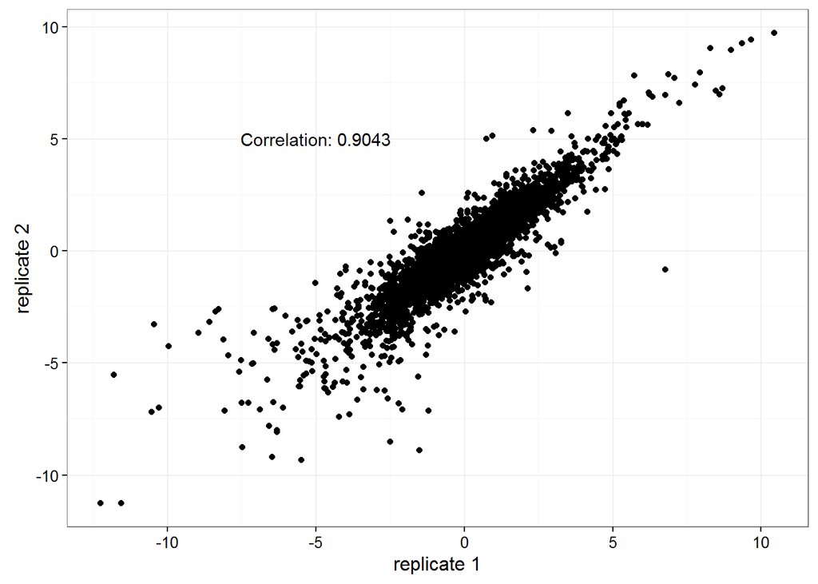

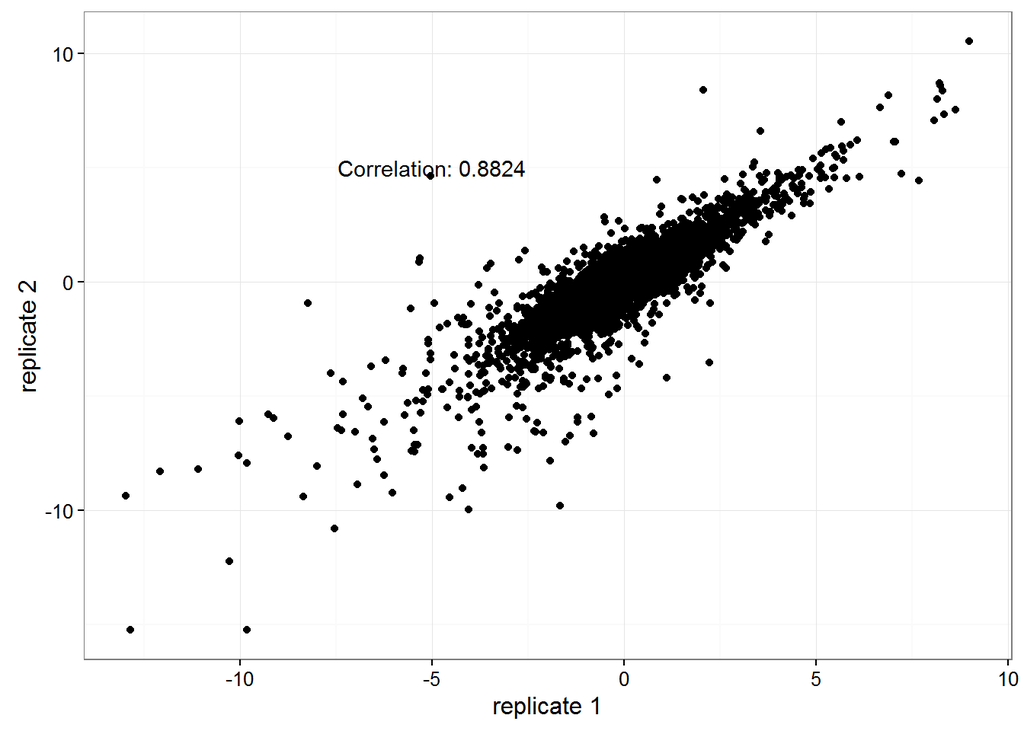

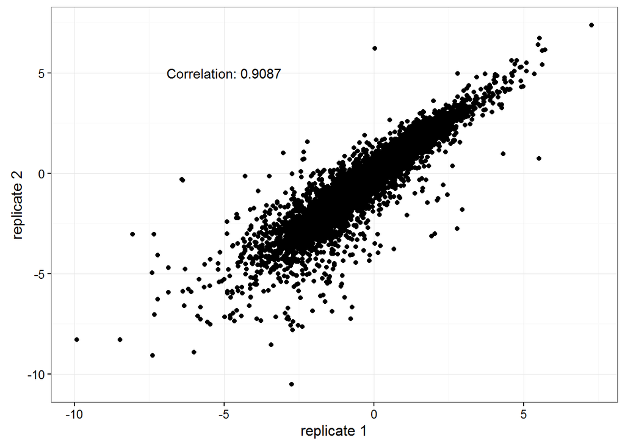

```r
tcors <- vector(mode = "numeric", length = 3)
avgtechreps <- matrix(data = NA, nrow = nrow(prot), ncol = 3)
colnames(avgtechreps) <- colnames(trepids)
rownames(avgtechreps) <- rownames(prot)
library(ggplot2)
for(i in 1:3) {
  trep <- prot[,trepids[,i] + 2L]
  avgtechreps[,i] <- rowMeans(trep)
  prot[,trepids[,i] + 2L] <- avgtechreps[,i]
  tcors[i] <- cor(trep[,1], trep[,2])
  print(qplot(x = trep[,1], y  = trep[,2]) + geom_point() +
          xlab("replicate 1")  + ylab("replicate 2") + theme_bw() +
           annotate("text", x = -5, y = 5, label =  paste0("Correlation: ", round(tcors[i], 4))))
}
```

The idMap object contains all 105 sample ids, excluding the 3 control samples, and indicates which is called a sufficiently high quality sample. Subset the 77 high quality samples. Assure the high quality samples agree between protein, CNA and RNA. The order of the samples for proteins does not natively match the RNA and CNA, which will be fixed here.

```r
#remove duplicate protein sample ids
pidnodups <- pid[!duplicated(pid)]
#assure high quality samples agree between protein,rna,cna
stopifnot(!length(setdiff(pidnodups, idMapHq$cnvOrder)))
#change the order of the protein sample columns
idMapHq$protOrder <- pidnodups[match(idMapHq$cnvOrder, pidnodups)]
```

Subset the high quality samples from the original import of the protein quantitation data.

```r
#pid
prot_hq <- prot[,c(1,2, match(idMapHq$protOrder, pid) + 2L)]
#assure ourselves that the sample ids match in the correct order of the protein expression matrix
tmp <- gsub(pattern = ".", replacement = "-", fixed = TRUE,
                      x = substr(x = colnames(prot_hq)[3:length(colnames(prot_hq))],
                                 start = 1, stop = 7))
stopifnot(identical(tmp, idMapHq$cnvOrder))
stopifnot(identical(tmp, idMapHq$rnaOrder))
stopifnot(identical(tmp, idMapHq$protOrder))
#match the simplified sample names now that we order has been assured.
colnames(prot_hq)[3:length(colnames(prot_hq))] <- tmp
```

Filter out all proteins but those that have variance in the top 20%.

```r
ed <- as.matrix(prot_hq[,3:ncol(prot_hq)])
#initial feature information
fd <-  data.frame( RefSeqProteinID = prot_hq[,2], description = prot_hq[,1],
                   row.names = prot_hq[,2])
protallset <- ExpressionSet(assayData = ed,
                         phenoData = pheno_data,
                         featureData = AnnotatedDataFrame(data = fd))
pexp <- exprs(protallset)
#no missing proteins
stopifnot(!any(is.na(pexp)))
sd_pexp <- apply(X = pexp, MARGIN = 1, FUN = sd)
keep_prot_index <- sd_pexp > quantile(x = sd_pexp, probs = 0.80)
protsdf <- protallset[which(keep_prot_index),]
protsdf
```

```
## ExpressionSet (storageMode: lockedEnvironment)
## assayData: 1595 features, 77 samples
##   element names: exprs
## protocolData: none
## phenoData
##   sampleNames: A2-A0CM A2-A0D2 ... E2-A15A (77 total)
##   varLabels: Sample iTRAQ.Experiment.number ... Center (13 total)
##   varMetadata: labelDescription
## featureData
##   featureNames: NP_112598 NP_001714 ... NP_997625 (1595 total)
##   fvarLabels: RefSeqProteinID description
##   fvarMetadata: labelDescription
## experimentData: use 'experimentData(object)'
## Annotation:
```

As seen in the `ExpressionSet object`, we have filtered out samples and protein features, added the phenotypic data, but have yet to add gene coordinates of the feature level information.

### Add gene coordinates of the protein features

Since the phenotypic data for the samples has been prepared earlier, arrange to annotate the protein features.

```r
library(Biobase)
library(mygene)
p2r77map <- queryMany(qterms = featureNames(protsdf), scopes = "refseq",
                      fields = c("entrezgene", "symbol"))
```

```
## Querying chunk 1
```

```
## Querying chunk 2
```

```
## Finished
## Pass returnall=TRUE to return lists of duplicate or missing query terms.
```

```r
p2r77map2 <- data.frame(refseq = p2r77map@listData$query, entrezgene = as.character(p2r77map@listData$entrezgene),
                        symbol = p2r77map@listData$symbol, stringsAsFactors = FALSE)
```

The RefSeq ID’s of the protein features is non-missing and unique.

```r
stopifnot(!any(is.na(p2r77map2$refseq)))
stopifnot(!any(duplicated(p2r77map2$refseq)))
```

On the other hand, some of the entrez gene ID’s are missing.

```r
missing_entrez_gene_ids <- p2r77map2$refseq[is.na(p2r77map2$entrezgene)]
length(missing_entrez_gene_ids)
```

```
## [1] 29
```

And duplication of entrez gene ID implies there are 194 isoforms.

```r
sum(duplicated(p2r77map2$entrezgene))
```

```
## [1] 194
```

Identify the protein features that are not missing entrez gene identifiers so that we can find their gene coordinates. List the isoforms for each of the 1400 features that ought to have gene coordinates.

```r
p2r77map3 <- p2r77map2[!is.na(p2r77map2$entrezgene),]
isoforms <- split(p2r77map3$refseq, f = as.factor(p2r77map3$entrezgene))
#unique entrez gene identifiers
egu <- names(isoforms)
```

Add the gene coordinate information as in the mRNA case where we have information available.

```r
get_protein_gene_coords <- function(egu, isoforms) {
  #find gene coordinate information for each unique entrez gene identifier
  yyids <- egu
  yy_chr <- hs_feature_list(org.Hs.egCHR, yyids)
  #assign to X
  yy_chr[[which(sapply(yy_chr, length) > 1)]] <- "X"
  yy_chr <- unlist(yy_chr)
  start_chrloc <- hs_feature_list(org.Hs.egCHRLOC, yyids)
  #get minimum start site
  min_start_chrloc <- sapply(start_chrloc, function(x) min(abs(x)))
  #strand information
  yy_strand <- ifelse(sapply(start_chrloc, function(x) sign(min(x))) == 1L, "+", "-")
  #get maximum end site
  end_chrloc <- hs_feature_list(org.Hs.egCHRLOCEND, yyids)
  max_start_chrloc <- sapply(end_chrloc, function(x) max(abs(x)))
  #get symbols
  yy_symbols <- unlist(hs_feature_list(org.Hs.egSYMBOL, yyids))

  #for each isoform provide gene coordinate information
  library(foreach)
  yy_node_attributes <- foreach(isos = isoforms, eg = names(isoforms), .combine= 'rbind') %do% {
    #if symbol does not exist for isoform, provide refseq id
    if (is.na(yy_symbols[eg])) {
      cys <- isos
    } else {
      cys <- yy_symbols[eg]
    }
    data.frame(id = isos,
               chr = paste0("chr", yy_chr[eg]),
               start = min_start_chrloc[eg],
               end = max_start_chrloc[eg],
               symbol = yy_symbols[eg],
               cyto = NA,
               cytoscape = cys,
               strand = yy_strand[eg],
               type = "y",
               stringsAsFactors = FALSE,
               row.names = NULL)
  }
  stopifnot(!any(is.na(yy_node_attributes$id)))

  #add missing feature values for those protein features that do not have gene coordinates
  missing_feats <- data.frame(id = missing_entrez_gene_ids,
                              chr = NA,
                              start = NA,
                              end = NA,
                              symbol = NA,
                              cyto = NA,
                              cytoscape = missing_entrez_gene_ids,
                              strand = NA,
                              type = "y",
                              stringsAsFactors = FALSE,
                              row.names = NULL)
  yy_node_attributes <- rbind(yy_node_attributes,missing_feats)
  #sort to match the feature order of the expression data
  yy_node_attributes[match(p2r77map2$refseq, yy_node_attributes$id),]
}
prot_gene_coordinates <- get_protein_gene_coords(egu, isoforms)
rownames(prot_gene_coordinates) <- prot_gene_coordinates$id
head(prot_gene_coordinates)
```

```
##                        id   chr     start       end symbol cyto cytoscape
## NP_112598       NP_112598  chr8 144939491 144952632  EPPK1   NA     EPPK1
## NP_001714       NP_001714  chr6  56322784  56819426    DST   NA       DST
## NP_002465       NP_002465 chr16  15796991  15950887  MYH11   NA     MYH11
## NP_001035202 NP_001035202 chr16  15796991  15950887  MYH11   NA     MYH11
## NP_001070654 NP_001070654 chr19  50706884  50813801  MYH14   NA     MYH14
## NP_079005       NP_079005 chr19  50706884  50813801  MYH14   NA     MYH14
##              strand type
## NP_112598         -    y
## NP_001714         -    y
## NP_002465         -    y
## NP_001035202      -    y
## NP_001070654      +    y
## NP_079005         +    y
```

We now form the final `ExpressionSet` for the protein quantitation data. Be sure to mean-center protein features and scale by the standard deviation.

```r
tmp <- pData(featureData(protsdf))
prot_node_attributes <- prot_gene_coordinates[match(tmp$RefSeqProteinID, prot_gene_coordinates$id),]
prot_node_attributes$description <- tmp$description
protset_no_std <- ExpressionSet(assayData = exprs(protsdf),
                                phenoData = pheno_data,
                                featureData = AnnotatedDataFrame(data =prot_node_attributes))
#n x p format
prot_expr_t <- t(exprs(protsdf))
#standardize and return to p x n format
prot_expr_std <- t(scale(prot_expr_t))
protset <- ExpressionSet(assayData = prot_expr_std,
                         phenoData = pheno_data,
                         featureData = AnnotatedDataFrame(data =prot_node_attributes))
```

## Process the Copy Number Alteration data.

In the copy number alteration data, we found that even after processing with the ‘Cluster along chromosomes algorithm’ (CLAC), there were still groupings of highly-correlated copy number alteration intervals (CNAI). We seek to further cluster these CNAI so that the extreme multicolinearity does not render the multivariate regression unstable.

### Multicolinearity detection of Copy Number Alteration Intervals

We will use a density-based clustering algorithm because it has a number of virtues:

- **Was developed for spatial correlation clustering of database records and extends well to CNAI application.**
- **No a priori knowledge of number of clusters.**
- **Allows for noise clusters which corresponds to independent random variables.**
- Scales to high dimension (fast).
- The distance function: 1 - |Correlation(X, Y)| is well-defined for multicolinearity detection.
- Clear Parametric Behavior: Episilon Parameter is very intuitive for defining how multicolinear variables are. `MinPnts` Parmater set to 2 to find even small blocks of multicolinearity.

The data has been previously loaded in the `pwf` environment. Create a temporary matrix `X` to store the CNA data.

```r
rownames(pwf$cnv.data) <- pwf$cnv.pos$Cyto
X <- t(pwf$cnv.data)
dim(X)
```

```
## [1]   77 1730
```

Match the samples order to that of the protein and mRNA data.

```r
sidx <- match(idMap$cnvOrder[idMap$highQual], substring(colnames(pwf$cnv.data), 6, 12))
X <- X[sidx,]
```

Assure ourselves again that the sample names match up now that we are working with the CNA output from CLAC.

```r
cna_sample_names <-  substring(colnames(pwf$cnv.data), 6, 12)[sidx]
rna_sample_names <-  sampleNames(rnaset)
stopifnot(identical(cna_sample_names, rna_sample_names))
```

Many variables have the same cytoband interval names.

```r
sum(duplicated(colnames(X)))
```

```
## [1] 862
```

Load the `fpc` package for using the `dbscan` algorithm. Define the dissimilarity to be `1 - minus Correlation`.

```r
library(fpc)
```

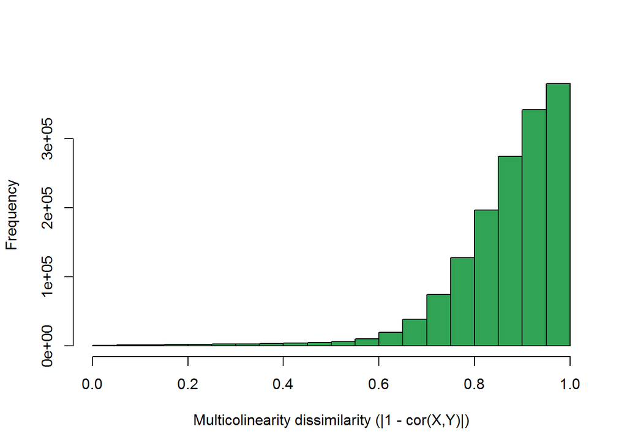

```r
dR <- 1 - abs(cor(X))
hist(dR[upper.tri(dR)], col = "#31a354", xlab = "Multicolinearity dissimilarity (|1 - cor(X,Y)|)", main = "")
```

We require a minimally small cluster of size 2 and a `reacheablility` radius of `1e-3`.

```r
clout <- dbscan(data = dR, MinPts = 2, eps = 1e-3, method = "dist")
```

The distribution on cluster size shows that most CNA are classified as sufficiently distinct from other CNA. This is desired behavior. Most extreme colinearity cases are limited to small clusters.

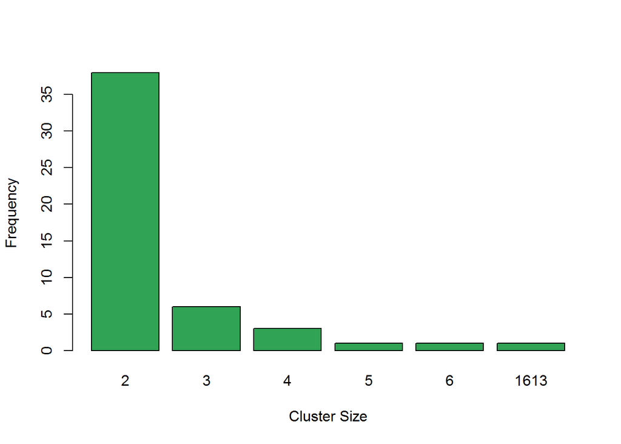

```r
barplot(table(table(clout$cluster)[]), col = "#31a354", xlab = "Cluster Size", ylab = "Frequency", main = "")
```

To get a sense of how much spatial correlation affects the multicolinear clusters, we compute a distance on the CNAI marker names. It is clear that most multicolinear clusters have the same interval name suggesting those intervals with similar distance will be clustered together.

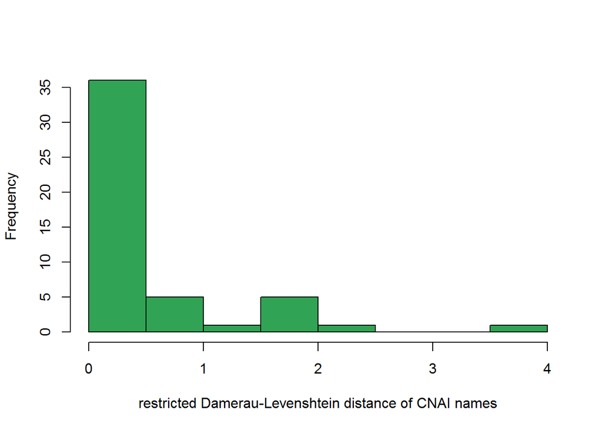

```r
suppressWarnings(library(stringdist))
library(foreach)
clusterDistr <- as.data.frame(table(clout$cluster), stringAsFactors = FALSE)
#Cluster `0` corresponds to sufficiently independent CNAI's. Omit it from the multi-colinear analysis.
mcolinear <- clusterDistr$Var1[2:nrow(clusterDistr)]
nameDist <- foreach(cl = mcolinear, .combine = 'c', .packages = c("stringdist")) %do% {
  cn <- colnames(X[,clout$cluster == cl])
  cnIdx <- seq_along(cn)

  nds <- length(cn) * (length(cn)  - 1) / 2
  sds <- numeric(nds)
  cntr <- 1
  for(i in cnIdx[-length(cnIdx)]) {
    for(j in (i + 1):length(cnIdx)) {
      #message(i,",", j)
      sds[cntr] <- stringdist(cn[i], cn[j])
      cntr <- cntr + 1
    }
  }
  mean(sds)
}
hist(nameDist, col="#31a354", xlab = "restricted Damerau-Levenshtein distance of CNAI names", main = "" )
```

We validate that the `eps` parameter behaves as we anticipated by computing the mean correlation of each multicolinear cluster.

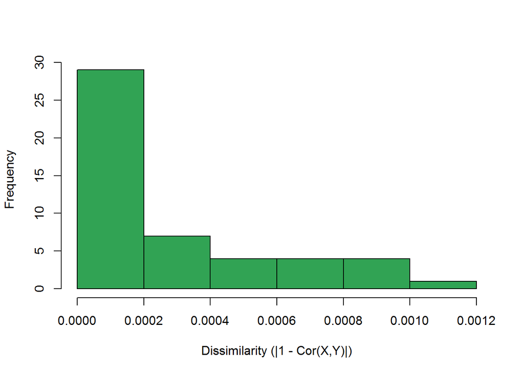

```r
clCorMeans <- foreach(cl = mcolinear, .combine = 'c') %do% {
  clcor <- cor(X[,clout$cluster == cl])
  mean(1 - clcor[upper.tri(clcor)])
}
hist(clCorMeans, col="#31a354", xlab = "Dissimilarity (|1 - Cor(X,Y)|)", main = "" )
```

#### Averaging Multicolinear Clusters

We will use the average of each mulitcolinear cluster to collapse (i.e. replace) the problematic CNAI into a single representative vector for future data analysis.

```r
avgMultiCol <- foreach(cl = mcolinear, .combine = 'cbind') %do% {
  rowMeans(X[,clout$cluster == cl])
}
```

#### Choose a representative interval name

Almost all of these multicolinear CNAI are contiguous. We resolve the interval names of the multicolinear CNAI by either (1) collapsing the identical interval names or (2) changing the interval names to reflect an expanded contiguous range of the multicolinear CNAI.

```r
namesMultiCol <- foreach(i = seq_along(mcolinear)) %do% {
  colnames(X[,clout$cluster == mcolinear[i]])
}
```

```r
toResolve <- namesMultiCol
namesMultiCol <- sapply(toResolve, function(x) paste0(unique(sort(unlist(strsplit(x=x, split = "-")))), collapse = "-"))
colnames(avgMultiCol) <- unlist(namesMultiCol)
```

Cluster `0` corresponds to sufficiently independent CNAI’s; these are combined with the collapsed multicolinear CNAI’s.

```r
#assure that combining avg. multi-colinear cna intervals with the non-multi-colinear intervals are matched by sample
stopifnot(identical(rownames(t(pwf$cnv.data)[sidx,]), rownames(avgMultiCol)))
cna <- t(cbind(t(pwf$cnv.data)[sidx,clout$cluster == 0],avgMultiCol))
```

The dimension of CNAI has now been reduced to 1662 from 1730 under this setting.

```r
dim(cna)
```

```
## [1] 1662   77
```

Assure that the averaging of multicolinear features preserved the sample order.

```r
cna_sample_names <-  substring(colnames(cna), 6, 12)
stopifnot(identical(cna_sample_names, substring(rownames(avgMultiCol), 6, 12)))
rna_sample_names <- sampleNames(rnaset)
stopifnot(identical(cna_sample_names, rna_sample_names))
```

### Annotate the genomic coordinates to enable cis/trans regulation.

Create unique ID’s for the genomic coordinates by appending the position coordinates in a _ format. If the multi-colinear cluster id is non-zero, then this CNA feature has been averaged by the analysis above.

```r
cnapos <- pwf$cnv.pos
cnaids <- apply( cnapos[ , c(1,2,3) ] , 1 , paste , collapse = "_" )
#add multicolinear ids
cnaids <- paste(cnaids,clout$cluster, sep = "_")
stopifnot(!anyDuplicated(cnaids))
str(cnaids)
```

```
##  chr [1:1730] "1_3218610_6972307_0" "1_6990271_14007849_0" ...
```

Confirm that multicolinear CNAI have no direct overlaps in the genome.

```r
suppressPackageStartupMessages(library(GenomicRanges))
gr <- GRanges(seqnames = Rle(paste0("chr", cnapos$ch.interval.iter2)),
              ranges = IRanges(start = cnapos$begin.nuc.iter2, end = cnapos$end.nuc.iter2,
                               names = cnapos$Cyto))
no_overlap <- all(sapply(mcolinear, function(mc) {
  grcl <- gr[clout$cluster == mc,]
  grclu <- unique(grcl)
  ov <- findOverlaps(grcl, grclu)
  identical(ov@to, ov@from)
}))
stopifnot(no_overlap)
```

Improve the cytoband information to be as non-redundant as possible.

```r
nr_cytobands <- function(cb) {
  split_cb <- unlist(strsplit(x = cb, split = "-"))
  if(length(split_cb) != 2) {
    return(cb)
  }

  split_cb2 <- unlist(strsplit(x = split_cb, split = "p|q"))
  pq1 <- regmatches(split_cb[1], m= regexpr(pattern = "[pq]+", text = split_cb[1]))
  pq2 <- regmatches(split_cb[2], m= regexpr(pattern = "[pq]+", text = split_cb[2]))
  same_arm <- pq1 == pq2
  chr1 <- split_cb2[1]
  chr2 <- split_cb2[3]
  same_chr <- chr1 == chr2
  loc1 <- as.numeric(split_cb2[2])
  loc2 <- as.numeric(split_cb2[4])
  same_loc <- loc1 == loc2

  if( same_chr & same_arm & same_loc) {
    paste0(chr1, pq1, loc1)
  } else if (same_chr & same_arm & !same_loc) {
    paste0(chr1, pq1, min(loc1,loc2), "-", max(loc1,loc2))
  } else if (same_chr & !same_arm & same_loc) {
    paste0(chr1, pq1, loc1, "-", pq2, loc2)
  } else if (same_chr & !same_arm & !same_loc) {
    paste0(chr1, pq1, loc1, "-", chr2, pq2, loc2)
  } else if (!same_chr) {
    paste0(chr1, pq1, loc1, "-", chr2, pq2, loc2)
  }
}
tmp <- data.frame(original = cnapos$Cyto, nr = sapply(cnapos$Cyto, nr_cytobands))
nr_cytoband_ids <- as.character(tmp$nr)
```

Format the CNA feature’s genomic coordinates in the same fashion as the protein and mRNA features.

```r
cna_node_attributes <- data.frame(id = cnaids,
                                 chr = paste0("chr", cnapos$ch.interval.iter2),
                                 start =  cnapos$begin.nuc.iter2,
                                 end = cnapos$end.nuc.iter2,
                                 symbol = NA,
                                 cyto = nr_cytoband_ids,
                                 strand = NA,
                                 type  = "x",
                                 cytoscape = nr_cytoband_ids,
                                 stringsAsFactors = FALSE)
#combine genomic coordinates in the same manner as the CNA data (inclusive of  multicolinear features )
cna_node_attributes2 <- cna_node_attributes[c(which(clout$cluster == 0), match(mcolinear, clout$cluster)),]
rownames(cna_node_attributes2) <- cna_node_attributes2$id
head(cna_node_attributes2)
```

```
##                                          id  chr    start      end symbol
## 1_3218610_6972307_0     1_3218610_6972307_0 chr1  3218610  6972307     NA
## 1_6990271_14007849_0   1_6990271_14007849_0 chr1  6990271 14007849     NA
## 1_14028633_28692959_0 1_14028633_28692959_0 chr1 14028633 28692959     NA
## 1_28695597_30387702_0 1_28695597_30387702_0 chr1 28695597 30387702     NA
## 1_30392887_31908168_0 1_30392887_31908168_0 chr1 30392887 31908168     NA
## 1_31909072_32155716_0 1_31909072_32155716_0 chr1 31909072 32155716     NA
##                                cyto strand type     cytoscape
## 1_3218610_6972307_0   1p36.31-36.32     NA    x 1p36.31-36.32
## 1_6990271_14007849_0  1p36.21-36.31     NA    x 1p36.21-36.31
## 1_14028633_28692959_0  1p35.3-36.21     NA    x  1p35.3-36.21
## 1_28695597_30387702_0   1p35.2-35.3     NA    x   1p35.2-35.3
## 1_30392887_31908168_0        1p35.2     NA    x        1p35.2
## 1_31909072_32155716_0        1p35.2     NA    x        1p35.2
```

Format the CNA data into an `ExpressionSet` object. Be sure to mean-center CNA features and scale by the standard deviation.

```r
colnames(cna) <- idMapHq$cnvOrder
rownames(cna) <- cna_node_attributes2$id
cnaset <- ExpressionSet(assayData = t(scale(t(cna))),
                        phenoData = pheno_data,
                        featureData =  AnnotatedDataFrame(data = cna_node_attributes2))
cnaset
```

```
## ExpressionSet (storageMode: lockedEnvironment)
## assayData: 1662 features, 77 samples
##   element names: exprs
## protocolData: none
## phenoData
##   sampleNames: A2-A0CM A2-A0D2 ... E2-A15A (77 total)
##   varLabels: Sample iTRAQ.Experiment.number ... Center (13 total)
##   varMetadata: labelDescription
## featureData
##   featureNames: 1_3218610_6972307_0 1_6990271_14007849_0 ...
##     18_46953239_47159916_49 (1662 total)
##   fvarLabels: id chr ... cytoscape (9 total)
##   fvarMetadata: labelDescription
## experimentData: use 'experimentData(object)'
## Annotation:
```

### Save cleaned data.

Save the `ExpressionSet` objects.

```r
basedir2 <- "~/repos/neta-bccptac/data/"
saveRDS(rnaset, file = file.path(basedir2, "rna-expression-set.rds"))
saveRDS(protset, file = file.path(basedir2, "prot-expression-set.rds"))
saveRDS(cnaset, file = file.path(basedir2, "cna-expression-set.rds"))
save(rnaset, protset, cnaset, file = file.path(basedir, "bccptac-expression-sets.RData"))
save.image(file = file.path(basedir, "data-cleaning-environment.RData"))
```